# DSF_Final_Report

## Churn Analysis

**Authors**

- Navya Chalamalasetty
- Saketh Reddy Dodda
- Pavan Kumar Malasani
- Kundan Sai Chowdary Sannapaneni
- Sai Preetham Vinnakota

## Introduction

Customer churn is an important business indicator, especially in industries where it is more expensive to acquire new customers than it is to retain existing ones.It simply measures the loss of customers, which can occur for a number of reasons, from dissatisfaction with services to better deals from competitors. In the era of digital transformation, when customer preferences and choices are constantly changing, businesses need to be more adaptive and attentive to these changes.They run the danger of seeing their churn rate rise if they don't. Churn not only affects the company's financial performance, but it may also be a sign of more serious problems with the company's business strategy, customer support, or product line.

## Goal

Perform a thorough analysis of our current customer dataset to identify the main factors causing churn. By identifying these patterns and contributing causes, we hope to get actionable insights that will guide and improve our customer retention tactics, resulting in increased customer satisfaction and a decrease in the churn rate in subsequent quarters.

## About Dataset

**Link to Data Set:** https://huggingface.co/datasets/scikit-learn/churn-prediction

The data meticulously describes the demographics, chosen services, and billing patterns of 7043 customers, illuminating their nuanced interactions with a telecommunications entity. Its central component is the Churn column, which identifies clients who have chosen to leave or remain. A balanced gender representation, a sizeable senior citizen population, and a range of service preferences for PhoneService, InternetService, and related offerings are among the key characteristics. The data is also further enhanced by financial touchpoints like MonthlyCharges and contractual commitments, as shown by the types and duration of contracts. Through the prism of this thorough tableau, we can understand the underlying drivers of a customer's loyalty or choice to depart.

- Churn is the name of the column that lists customers who have left in the past month.
- Services that each customer has signed up for: a phone, multiple lines, an internet connection, online backup and security, device protection, tech support, and on-demand TV and movie streaming.
- Customer account information: the duration of their contract, payment method, paperless billing, monthly charges, and overall charges.
- Demographic info about customers: Gender, age range, and whether they are married or have children.

## Potential Sources of Bias in the Data Set

1. **Representation Bias**:
   - Underrepresentation of some customer demographics, such as those without phone service.
   - About 70% of customers are single, which may not accurately reflect the customer base.
2. **Data Quality Bias**:
   - "TotalCharges" column contains 11 empty strings in place of missing data, which may induce bias if the missingness is not random.
3. **Outcome Bias**:
   - Features like "MonthlyCharges," "PaperlessBilling," and "SeniorCitizen" are significantly correlated with churn. Models trained on this dataset may inherit any inherent biases in these features.

To achieve a more balanced and representative sample, addressing these biases necessitates domain expertise and perhaps extra data.

```python
# Import the libraries
import pandas as pd
import numpy as np
import matplotlib.pyplot as plt
import seaborn as sns
```

```python
# Load Data sets
data = pd.read_csv("Churn main dataset.csv")
data.head()
```

|  | customerID | gender | SeniorCitizen | Partner | Dependents | tenure | PhoneService | MultipleLines | InternetService | OnlineSecurity | ... | DeviceProtection | TechSupport | StreamingTV | StreamingMovies | Contract | PaperlessBilling | PaymentMethod | MonthlyCharges | TotalCharges | Churn |
| --- | --- | --- | --- | --- | --- | --- | --- | --- | --- | --- | --- | --- | --- | --- | --- | --- | --- | --- | --- | --- | --- |
| 0 | 7590-VHVEG | Female | 0 | Yes | No | 1 | No | No phone service | DSL | No | ... | No | No | No | No | Month-to-month | Yes | Electronic check | 29.85 | 29.85 | No |
| 1 | 5575-GNVDE | Male | 0 | No | No | 34 | Yes | No | DSL | Yes | ... | Yes | No | No | No | One year | No | Mailed check | 56.95 | 1889.5 | No |
| 2 | 3668-QPYBK | Male | 0 | No | No | 2 | Yes | No | DSL | Yes | ... | No | No | No | No | Month-to-month | Yes | Mailed check | 53.85 | 108.15 | Yes |
| 3 | 7795-CFOCW | Male | 0 | No | No | 45 | No | No phone service | DSL | Yes | ... | Yes | Yes | No | No | One year | No | Bank transfer (automatic) | 42.30 | 1840.75 | No |
| 4 | 9237-HQITU | Female | 0 | No | No | 2 | Yes | No | Fiber optic | No | ... | No | No | No | No | Month-to-month | Yes | Electronic check | 70.70 | 151.65 | Yes |

5 rows × 21 columns

## Understanding and Cleaning of Data

```python
# Listing the Unique values from each column as list
unique=[]
for a in data.columns:
    unique.append(data[a].unique())
unique
```

```
[array(['7590-VHVEG', '5575-GNVDE', '3668-QPYBK', ..., '4801-JZAZL',
        '8361-LTMKD', '3186-AJIEK'], dtype=object),
 array(['Female', 'Male'], dtype=object),
 array([0, 1], dtype=int64),
 array(['Yes', 'No'], dtype=object),
 array(['No', 'Yes'], dtype=object),
 array([ 1, 34,  2, 45,  8, 22, 10, 28, 62, 13, 16, 58, 49, 25, 69, 52, 71,
        21, 12, 30, 47, 72, 17, 27,  5, 46, 11, 70, 63, 43, 15, 60, 18, 66,
         9,  3, 31, 50, 64, 56,  7, 42, 35, 48, 29, 65, 38, 68, 32, 55, 37,
        36, 41,  6,  4, 33, 67, 23, 57, 61, 14, 20, 53, 40, 59, 24, 44, 19,
        54, 51, 26,  0, 39], dtype=int64),
 array(['No', 'Yes'], dtype=object),
 array(['No phone service', 'No', 'Yes'], dtype=object),
 array(['DSL', 'Fiber optic', 'No'], dtype=object),
 array(['No', 'Yes', 'No internet service'], dtype=object),
 array(['Yes', 'No', 'No internet service'], dtype=object),
 array(['No', 'Yes', 'No internet service'], dtype=object),
 array(['No', 'Yes', 'No internet service'], dtype=object),
 array(['No', 'Yes', 'No internet service'], dtype=object),
 array(['No', 'Yes', 'No internet service'], dtype=object),
 array(['Month-to-month', 'One year', 'Two year'], dtype=object),
 array(['Yes', 'No'], dtype=object),
 array(['Electronic check', 'Mailed check', 'Bank transfer (automatic)',
        'Credit card (automatic)'], dtype=object),
 array([29.85, 56.95, 53.85, ..., 63.1 , 44.2 , 78.7 ]),
 array(['29.85', '1889.5', '108.15', ..., '346.45', '306.6', '6844.5'],
       dtype=object),
 array(['No', 'Yes'], dtype=object)]
```

```python
# Information about Data set
data.info()
```

```
<class 'pandas.core.frame.DataFrame'>
RangeIndex: 7043 entries, 0 to 7042
Data columns (total 21 columns):
 #   Column            Non-Null Count  Dtype
---  ------            --------------  -----
 0   customerID        7043 non-null   object
 1   gender            7043 non-null   object
 2   SeniorCitizen     7043 non-null   int64
 3   Partner           7043 non-null   object
 4   Dependents        7043 non-null   object
 5   tenure            7043 non-null   int64
 6   PhoneService      7043 non-null   object
 7   MultipleLines     7043 non-null   object
 8   InternetService   7043 non-null   object
 9   OnlineSecurity    7043 non-null   object
 10  OnlineBackup      7043 non-null   object
 11  DeviceProtection  7043 non-null   object
 12  TechSupport       7043 non-null   object
 13  StreamingTV       7043 non-null   object
 14  StreamingMovies   7043 non-null   object
 15  Contract          7043 non-null   object
 16  PaperlessBilling  7043 non-null   object
 17  PaymentMethod     7043 non-null   object
 18  MonthlyCharges    7043 non-null   float64
 19  TotalCharges      7043 non-null   object
 20  Churn             7043 non-null   object
dtypes: float64(1), int64(2), object(18)
memory usage: 1.1+ MB
```

```python
# Creating a new DataFrame for analyzing Internet services and basic internet accessories
exp=data[['InternetService','OnlineSecurity','OnlineBackup','DeviceProtection','TechSupport','StreamingTV','StreamingMovies']]
exp.head()
```

|  | InternetService | OnlineSecurity | OnlineBackup | DeviceProtection | TechSupport | StreamingTV | StreamingMovies |
| --- | --- | --- | --- | --- | --- | --- | --- |
| 0 | DSL | No | Yes | No | No | No | No |
| 1 | DSL | Yes | No | Yes | No | No | No |
| 2 | DSL | Yes | Yes | No | No | No | No |
| 3 | DSL | Yes | No | Yes | Yes | No | No |
| 4 | Fiber optic | No | No | No | No | No | No |

```python
# Assuming "yes" for types of InternetService  with 3 or more Serices
# Only apply the lambda function to string columns
exp['res'] = exp.select_dtypes(include=['object']).apply(lambda row: row.str.count('Yes').sum(), axis=1).apply(lambda x: "1" if x > 2 else "0")
exp.head()
```

|  | InternetService | OnlineSecurity | OnlineBackup | DeviceProtection | TechSupport | StreamingTV | StreamingMovies | res |
| --- | --- | --- | --- | --- | --- | --- | --- | --- |
| 0 | DSL | No | Yes | No | No | No | No | 0 |
| 1 | DSL | Yes | No | Yes | No | No | No | 0 |
| 2 | DSL | Yes | Yes | No | No | No | No | 0 |
| 3 | DSL | Yes | No | Yes | Yes | No | No | 1 |
| 4 | Fiber optic | No | No | No | No | No | No | 0 |

```
res                 0     1
InternetService
DSL              1163  1258
Fiber optic      1529  1567
```

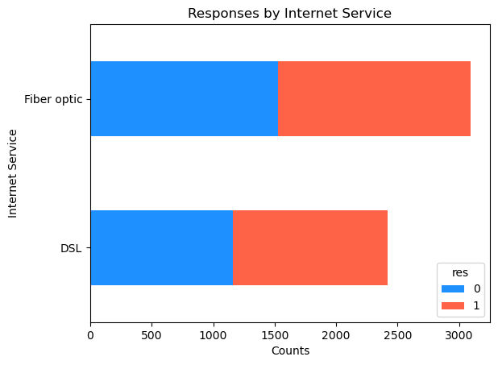

```python
# Generating a plot depicting the count of users utilizing internet for their minimal services
exp=exp.drop(exp[exp['InternetService']=='No'].index)
counts = exp.groupby('InternetService')['res'].value_counts().unstack()
print(counts)
# Plot bar chart
ax = counts.plot(kind='barh', stacked=True,color = ['dodgerblue','tomato'])
ax.set_xlabel('Counts')
ax.set_ylabel('Internet Service')
ax.set_title('Responses by Internet Service')

plt.show()
```

The data is then organized into groups according to the `InternetService (DSL or Fiber optic)` type and further divided according to the `res` (Above created Data Frame for visulation) values. The distribution of positive comments for each internet service type is shown by this aggregated data, which is kept as counts.

To illustrate the distribution of responses for each internet service, a horizontal stacked bar chart is plotted as a final step. Based on the customer's choice of internet service, this visualization helps to understand how engaged they are with the company's services.

A stacked bar plot was chosen for this insight because it provides both a broad and segmented view. It layers categories, like `res` values, within more inclusive groups, like `InternetService`, making it easier to make direct comparisons. This structure highlights differences in positive responses across service types and clarifies individual and combined totals. Its small size and adaptable construction also allow for future analyses' potential expansions.

```python
# Update the Churn column values: "Yes" to "1" and "No" to "0"
data['Churn']=data['Churn'].apply(lambda x: 1 if x=="Yes" else 0)
```

[figure not shown]

```python
# Data Grouping
counts = data.groupby(['gender', 'Churn']).size().unstack()

# Extracting values for plotting
male_churn = counts.loc['Male']
female_churn = counts.loc['Female']


# Plotting with labels set on the pies
fig, ax = plt.subplots(figsize=(10, 6))

# Male Churn
ax.pie(male_churn, labels=['Churned - Male', 'Not Churned - Male'], startangle=10,
       autopct='%1.1f%%', wedgeprops=dict(width=0.3), colors = ['red', 'blue'], radius=1.2, labeldistance=0.9)
# Female Churn
ax.pie(female_churn, labels=['Churned - Female', 'Not Churned - Female'], startangle=90,
       autopct='%1.1f%%', wedgeprops=dict(width=0.3), colors = ['gold', 'limegreen'] , radius=0.9, labeldistance=0.2)

# Title
ax.set_title('Churn Rates by Gender', size=15)


plt.tight_layout()
plt.show()
```

```python
# Categorizing 'MonthlyCharges' into four distinct ranges for analysis and visualization
data['MonthlyCharges']=data['MonthlyCharges'].apply(lambda x: "0-30" if x<30 else("30-60" if 30<=x<60 else("60-90" if 60<=x<90 else "90-120")))
data.head()
```

|  | customerID | gender | SeniorCitizen | Partner | Dependents | tenure | PhoneService | MultipleLines | InternetService | OnlineSecurity | ... | DeviceProtection | TechSupport | StreamingTV | StreamingMovies | Contract | PaperlessBilling | PaymentMethod | MonthlyCharges | TotalCharges | Churn |
| --- | --- | --- | --- | --- | --- | --- | --- | --- | --- | --- | --- | --- | --- | --- | --- | --- | --- | --- | --- | --- | --- |
| 0 | 7590-VHVEG | Female | 0 | Yes | No | 1 | No | No phone service | DSL | No | ... | No | No | No | No | Month-to-month | Yes | Electronic check | 0-30 | 29.85 | 0 |
| 1 | 5575-GNVDE | Male | 0 | No | No | 34 | Yes | No | DSL | Yes | ... | Yes | No | No | No | One year | No | Mailed check | 30-60 | 1889.5 | 0 |
| 2 | 3668-QPYBK | Male | 0 | No | No | 2 | Yes | No | DSL | Yes | ... | No | No | No | No | Month-to-month | Yes | Mailed check | 30-60 | 108.15 | 1 |
| 3 | 7795-CFOCW | Male | 0 | No | No | 45 | No | No phone service | DSL | Yes | ... | Yes | Yes | No | No | One year | No | Bank transfer (automatic) | 30-60 | 1840.75 | 0 |
| 4 | 9237-HQITU | Female | 0 | No | No | 2 | Yes | No | Fiber optic | No | ... | No | No | No | No | Month-to-month | Yes | Electronic check | 60-90 | 151.65 | 1 |

5 rows × 21 columns

```
Churn              0    1
MonthlyCharges
0-30            1491  162
30-60            904  350
60-90           1488  904
90-120          1009  735
```

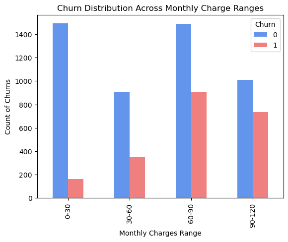

```python
# Grouping the data by the categorized 'MonthlyCharges' ranges to get the churn count for each range and then visualizing the distribution using a stacked bar chart.

counts = data.groupby('MonthlyCharges')['Churn'].value_counts().unstack()
counts=counts.sort_values(by='MonthlyCharges',ascending=True)
print(counts)

ax = counts.plot(kind='bar',color = ['cornflowerblue','lightcoral'])
ax.set_xlabel('Monthly Charges Range')
ax.set_ylabel('Count of Churns')
ax.set_title('Churn Distribution Across Monthly Charge Ranges')

plt.show()
```

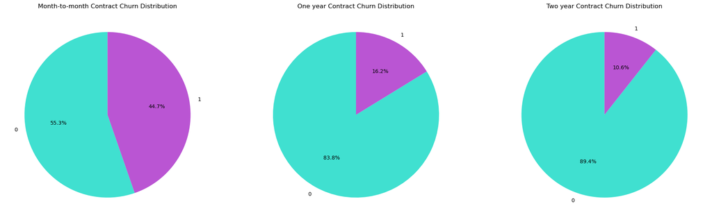

```python
# Pie Chart for each Contract type
fig, ax = plt.subplots(nrows=1, ncols=3, figsize=(20, 6))
counts = data.groupby('Contract')['Churn'].value_counts().unstack()

# Month-to-month
ax[0].pie(counts.loc['Month-to-month'], labels=counts.columns, autopct='%1.1f%%', startangle=90,colors = ['turquoise','mediumorchid'])
ax[0].set_title('Month-to-month Contract Churn Distribution')

# One year
ax[1].pie(counts.loc['One year'], labels=counts.columns, autopct='%1.1f%%', startangle=90,colors = ['turquoise','mediumorchid'])
ax[1].set_title('One year Contract Churn Distribution')

# Two year
ax[2].pie(counts.loc['Two year'], labels=counts.columns, autopct='%1.1f%%', startangle=90,colors = ['turquoise','mediumorchid'])
ax[2].set_title('Two year Contract Churn Distribution')

plt.tight_layout()
plt.show()
```

Insightful trends can be seen in the pie charts showing the distribution of churn over various contract lengths. Customers on month-to-month contracts experience the highest customer churn, indicating that the short-term nature of these contracts makes it simpler for customers to leave. On the other hand, individuals with one-year contracts exhibit a moderate rate of churn, indicating a reasonable level of satisfaction and commitment. Most significantly, two-year contracts, which have the lowest churn rate, show a strong sense of customer loyalty, perhaps motivated by the value or benefits they receive. Collectively, these findings highlight the importance of fostering long-term relationships with clients in order to increase retention.

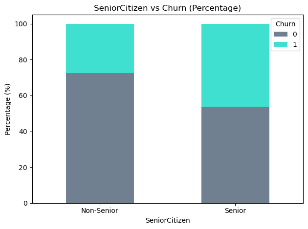

```python
# Group the data by 'SeniorCitizen' and 'Churn' and get the counts
gender_churn_counts = data.groupby(['SeniorCitizen', 'Churn']).size().unstack()

# Convert the counts to percentages
gender_churn_percentages = gender_churn_counts.divide(gender_churn_counts.sum(axis=1), axis=0) * 100

# Plotting the stacked bar chart with percentages again
gender_churn_percentages.plot(kind='bar', stacked=True,color = ['slategrey','turquoise'])

# Adding labels, title, and other aesthetics
plt.xlabel('SeniorCitizen')
plt.ylabel('Percentage (%)')
plt.title('SeniorCitizen vs Churn (Percentage)')
plt.legend(title="Churn")
plt.xticks(ticks=[0,1], labels=["Non-Senior", "Senior"], rotation=0)
plt.tight_layout()

# Display the plot
plt.show()
```

Several conclusions can be drawn from the stacked bar chart showing the churn rates for senior citizens and non-senior citizens. Notably, compared to their younger counterparts, seniors show a significantly higher tendency to churn. While almost half (46.15%) of senior citizens chose to churn, only about a quarter (27.52%) of non-senior citizens did the same. This significant difference suggests that factors affecting customer retention may differ between these demographic groups. To improve their retention rates, service providers may need to use different tactics or provide customized services to address the special preferences and needs of senior citizens.

## Detailed Analysis

In this comprehensive analysis, we examine patterns of customer churn, looking at how tenure and service subscriptions affect retention. By examining the tenure distribution against churn rates and assessing the impact of key add-on services, we unveil pivotal insights that shed light on customer behavior and the underlying factors driving their loyalty.

[figure not shown]

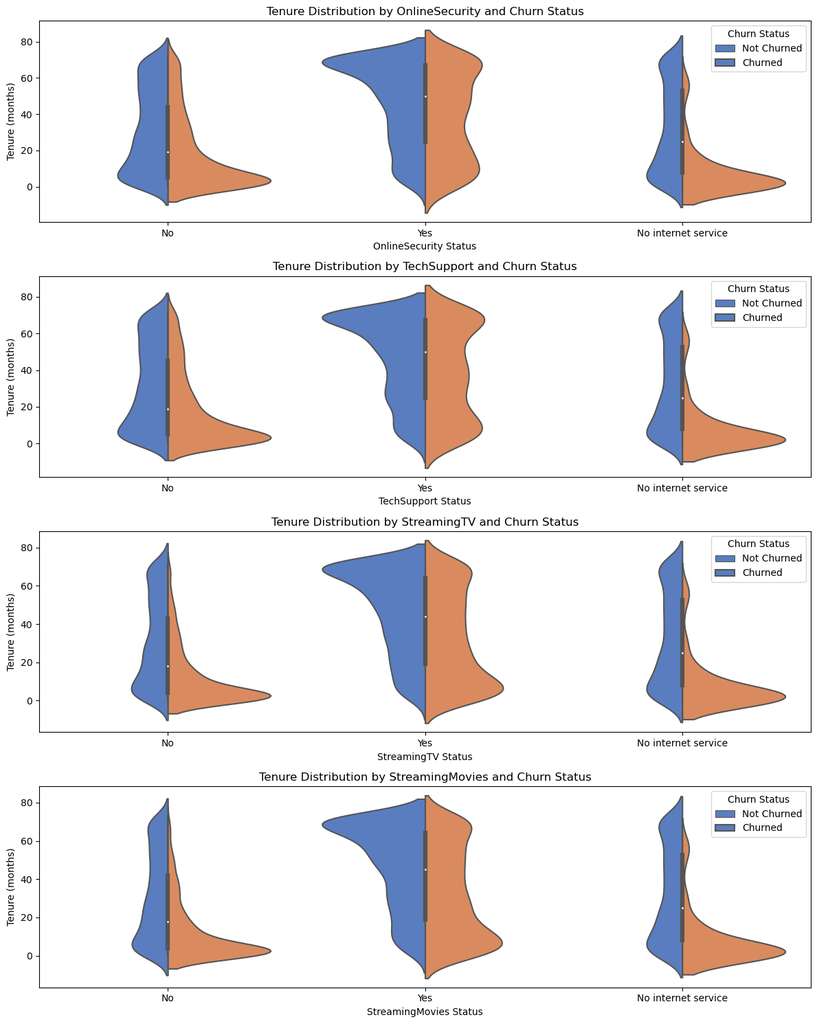

```python
# Plotting the distribution of tenure for churned vs not churned customers
plt.figure(figsize=(12, 7))
sns.histplot(data=data, x='tenure', hue='Churn', element='step', stat='density', common_norm=False)

# Title and labels
plt.title('Distribution of Tenure by Churn Status', size=15)
plt.xlabel('Tenure (months)')
plt.ylabel('Density')
plt.legend(title='Churn Status', labels=['Not Churned', 'Churned'])

plt.tight_layout()
plt.show()

# Next, the violin plots for each add-on service
services = ['OnlineSecurity', 'TechSupport', 'StreamingTV', 'StreamingMovies']
fig, axs = plt.subplots(nrows=len(services), figsize=(12, 15))

for i, service in enumerate(services):
    sns.violinplot(data=data, x=service, y='tenure', hue='Churn', split=True, ax=axs[i], palette="muted")
    axs[i].set_title(f'Tenure Distribution by {service} and Churn Status')
    axs[i].set_ylabel('Tenure (months)')
    axs[i].set_xlabel(f'{service} Status')
    axs[i].legend(title='Churn Status', labels=['Not Churned', 'Churned'])

plt.tight_layout()
plt.show()
```

**The Role of Add-On Services in Shaping Customer Loyalty:**

Insights into a customer's priorities and level of satisfaction can be gained by looking more closely at the services they subscribe to. Two stand out among the many services because of their notable effects on client retention: Technical assistance and online security. There is no denying the allure of online safety. The importance of protecting one's data and online activities grows in a world that is becoming more and more digital. Customers who subscribe to online security services can feel secure knowing that potential threats to their digital footprint are prevented. This not only increases the perceived usefulness of the service but also fosters trust. The availability of technical support also becomes apparent as a key element in customer satisfaction. Regardless of how well a service is done, problems will always arise. The availability of quick and helpful tech support in these circumstances can mean the difference between a minor irritation and a deal-breaker. By ensuring that customers spend as little time wrangling with problems as possible, it promotes a seamless experience. For entertainment services like streaming TV and streaming movies, it is impossible to make the same claim. Despite being well-liked, they don't appear to anchor clients in the same way. Similar content is available on numerous platforms, which reduces its exclusivity and appeal.